# Imaging

## 11/10/2022

print view

[figure not shown]

# Images

Images are composed of *pixels* (pix - picture, el - element).

In a grayscale image the pixel contains the intensity. Depending on the image format this may range from 0-1, 0-255, or be any floating point number.

In a color image a pixel is (usually) a triple (red,green,blue) of color values where each color intensity ranges from 0-255 (24-bit color).

# A slightly irrelevant aside

### Or, how to count with 16 fingers

It is very common for RGB color values to be represented in hexadecimal (e.g., HTML).

Hexadecimal number are usually indicated with a `0x` or `#` prefix.

In hexadecimal, each digit can take one of 16 values (as opposed to 10). This means that each color can be represented with two digits (16*16 = 256)

https://www.youtube.com/watch?v=ffB0Je-xjKg

| A | 10 |
| --- | --- |
| B | 11 |
| C | 12 |
| D | 13 |
| E | 14 |
| F | 15 |

# Answers

```
31 254
```

`<div style="color: #ff00ff">Hello</div>`

Hello

# PIL - The Python Image Library

[documentation](http://effbot.org/imagingbook/pil-index.htm)

The Python Imaging Library provides the ability to read, write an manipulate images in all the common formats. Some key modules:

- PIL.Image - primary Image object
- PIL.ImageChops - channel operations, for blending two images
- PIL.ImageEnhance - enhance your photos (sharpness, contrast, ...)
- PIL.ImageFilter - filters (blur, smooth, sharpen, ...)
- PIL.ImageOps - assorted operations (resizing, equalize, autocontrast, ...)
- PIL.ImageStat - statistics on image (min, max, ...)

# History

Despite being a popular package, PIL development stopped in 2011 with no new releases since 2009.

**Pillow** is a fork of PIL that is fully backwards compatible and updated (and is what you are actually using rather than the original PIL).

https://python-pillow.org

# Setup...

Download: http://bits.csb.pitt.edu/images/image1.tif

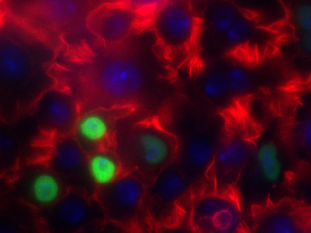

Actin HSP27 DAPI

# Image Methods

PIL refers to the different color channels as *bands*.

```
('R', 'G', 'B')
```

You can split a color image into it's separate bands.

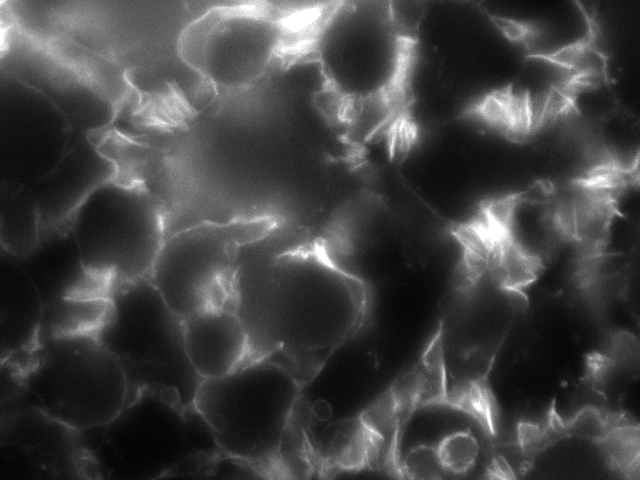

## Green

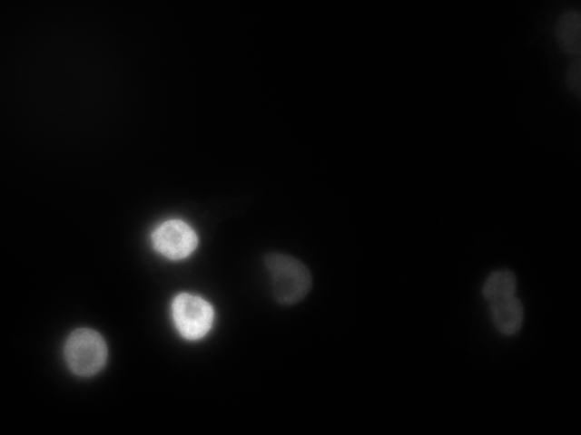

# Blue

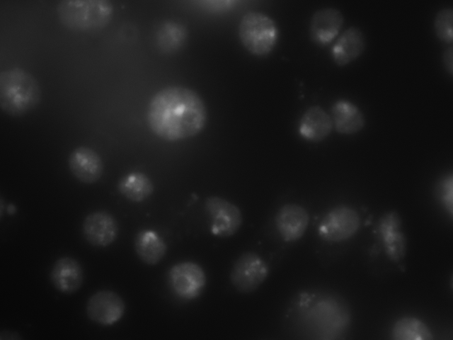

# Converting Image Types

We can convert to grayscale ('L' - luminance)

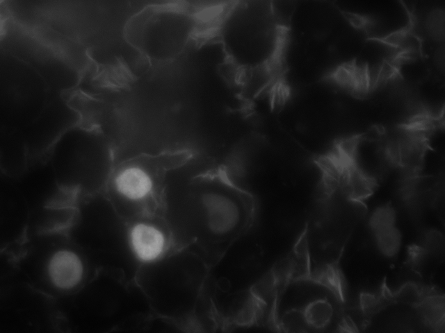

# Getting Pixels

```
(640, 480)
```

```
(159, 3, 18)
```

# Setting Pixels

To get/set pixels directly, first load the pixel map of an image.

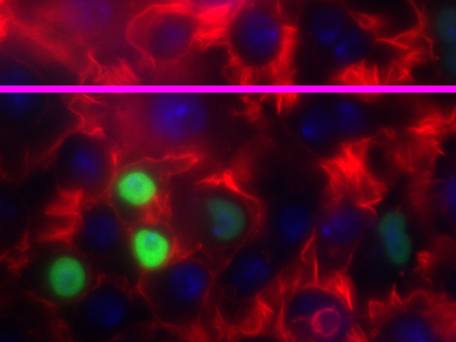

# Getting all the pixels

Can convert to `numpy` array - first dimension (rows) will be y-axis

```
(480, 640, 3)
```

```
array([159,   3,  18], dtype=uint8)
```

Can get all the pixels in a flat list

```
[(243, 3, 28),
 (238, 3, 27),
 (242, 3, 26),
 (239, 3, 27),
 (226, 3, 27),
 (220, 3, 26),
 (195, 3, 27),
 (179, 3, 26),
 (171, 3, 27),
 (163, 4, 28),
 (163, 3, 27),
 (148, 3, 28),
 (145, 4, 27),
 (146, 3, 27),
 (137, 4, 27),
 (136, 4, 27),
 (136, 3, 28),
 (124, 4, 28),
 (125, 4, 28),
 (121, 3, 27),
 (116, 4, 28),
 (113, 4, 26),
 (107, 3, 28),
 (107, 4, 27),
 (103, 3, 29),
 (96, 3, 28),
 (93, 3, 30),
 (95, 3, 27),
 (87, 3, 28),
 (94, 3, 28),
 (91, 3, 27),
 (94, 3, 28),
 (87, 3, 27),
 (93, 3, 28),
 (82, 3, 27),
 (79, 3, 28),
 (78, 4, 27),
 (84, 4, 28),
 (79, 4, 29),
 (85, 4, 28),
```

[output cut: 946 more lines]

```
 (138, 1, 48),
 (140, 1, 48),
 (134, 1, 48),
 (127, 1, 48),
 (129, 1, 48),
 (118, 1, 46),
 (129, 1, 43),
 (121, 1, 43),
 (107, 1, 42),
 (109, 1, 42),
 (110, 1, 42),
 (102, 1, 43),
 (103, 1, 40),
 (103, 1, 40),
 ...]
```

## Let's say we want the max value in blue channel

```
192
```

```
192
```

```
[(6, 192)]
```

# Histograms

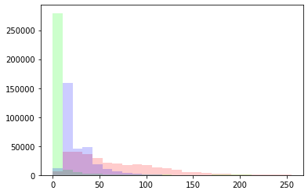

# More Histograms

```
[6, 14, 62, 172, 316, 517, 772, 1021, 1206, 1361, 1636, 2009, 2383, 2726, 3149, 3529, 3948, 4202, 4524, 4574]
```

```
(0.0, 24000.0)
```

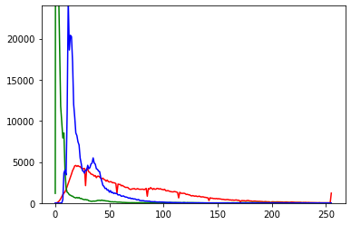

# Equalization

Equalization attempts to normalizes the image histogram to create a uniform distribution of grayscale values. This makes it easier to see differences, but distorts the meaning of the intensities (the transformation is non-linear).

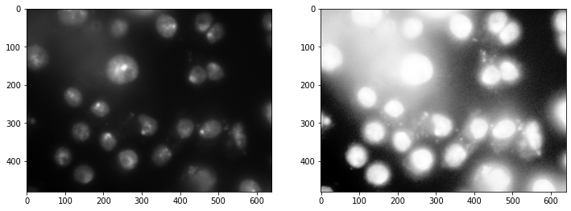

# Equalization

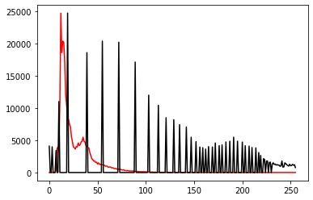

# Autocontrast

Maximize (normalize) image contrast. This function calculates a histogram of the input image, removes a cutoff percent of the lightest and darkest pixels from the histogram, and remaps the image so that the darkest remaining pixel becomes black (0), and the lightest becomes white (255).

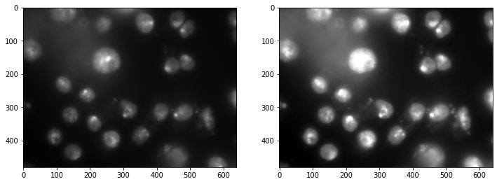

# Autocontrast

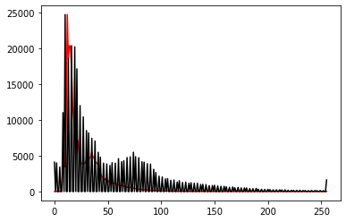

# Thresholding

The `point` function can be used to apply a function to every pixel in the image and return the transformed image. This makes it easy to threshold images into a mask.

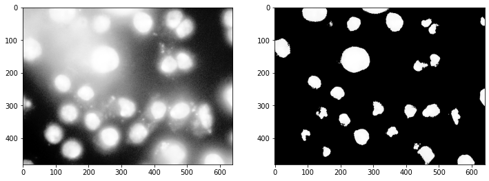

Looking at the thresholded image, any thoughts on how to count the number of cells?

# Project

- How much green is there in image1 (sum of values)?
- Get the other three images from http://bits.csb.pitt.edu/images
- How much green is there that is co-located with blue > 40? As a percentage? For each image?
- What if we change the cutoff (40)?
- Plot the percentage of green co-located with blue for different values of the blue cutoff for each image.

```
Sums for R: 20590309, G: 2241565, B: 8077411
```

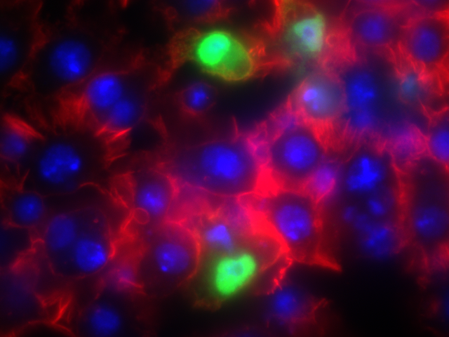

```
Sums for R: 21396630, G: 4120230, B: 16723255
```

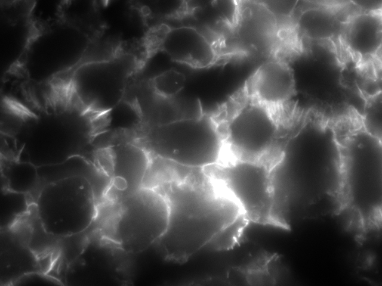

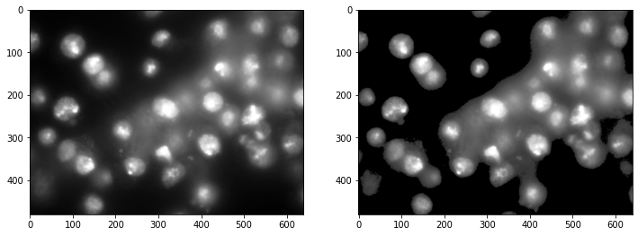

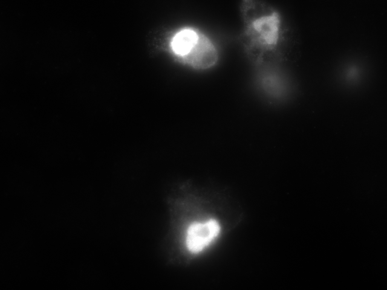

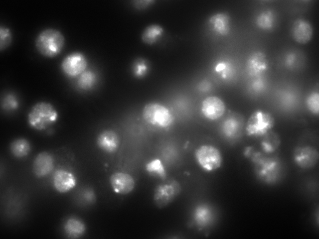

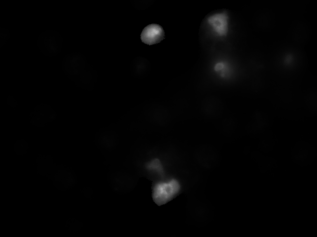

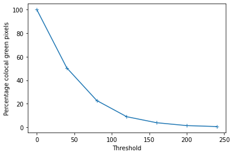